# Steam Games Dataset

## Wczytywanie i parsowanie datasetu

## O datasecie

Zbiór danych zawiera informacje o grach wydanych na platformie Steam od czerwca 1997 r. do połowy marca 2026 r.

- Żródło: https://www.kaggle.com/datasets/ebrucakar/steam-games-dataset-march-2026
- Surowy plik CSV: **390 MB**, **40 kolumn, 115289 wierszy**
- Informacje o grach: nazwa, data premiery, wydawca, deweloper, obsługiwane języki, oceny Metacritic oraz Steam i inne
- Dane zebrane za pomocą **Steam API** i **Steam Spy**

W tym projekcie skupiliśmy się na analizie wybranych zmiennych jakościowych i ilościowych.

## Wczytywanie pliku i wybór kolumn

```r
games <- read_csv("games.csv")
cat("Wymiary przed czyszczeniem:", nrow(games), "wierszy ×", ncol(games), "kolumn\n")
```

```
## Wymiary przed czyszczeniem: 115289 wierszy × 40 kolumn
```

```r
games <- games %>%
  dplyr::select(-c(`Required age`, `About the game`, `Reviews`, `Header image`,
                   `Website`, `Support url`, `Support email`, `Metacritic url`,
                   `Notes`, `Screenshots`, `Movies`, `Score rank`,`Full audio languages`,                                 `Supported languages`,`User score`)) %>%

  rename_with(~ gsub(" ", "_", .x)) # replace " " with _ in column names for clearer access
```

## Funkcja pomocnicza do parsowania kolumn z Python’owymi listami

```r
parse_list_column <- function(x) {
  lapply(x, function(val) {
    if (is.na(val) || val == "" || val == "[]") return(character(0))
    if (startsWith(trimws(val), "[")) {
      inner   <- gsub("^\\[|\\]$", "", trimws(val))
      matches <- regmatches(inner, gregexpr("'([^']*)'", inner))[[1]]
      items   <- gsub("^'|'$", "", matches)
    } else {
      items <- strsplit(val, ",")[[1]]
    }
    trimws(items)
  })
}
```

## Parsowanie typów

```r
games <- games %>%
  mutate(Windows = as.logical(Windows), Mac = as.logical(Mac), Linux = as.logical(Linux))   %>%
  mutate(Release_date = mdy(Release_date)) %>% # numeric
  mutate(across(c(Peak_CCU, Price, Discount, DLC_count, Metacritic_score,
                  Positive, Negative, Achievements,
                  Average_playtime_forever, Average_playtime_two_weeks,
                  Median_playtime_forever, Median_playtime_two_weeks), as.numeric)) %>%
  mutate(Developers           = parse_list_column(Developers), # list processing
         Publishers           = parse_list_column(Publishers),
         Categories           = parse_list_column(Categories),
         Genres               = parse_list_column(Genres),
         Tags                 = parse_list_column(Tags)) %>%
  mutate(Positive_Percent = 100 * Positive / (Positive + Negative)) # Adding new column
```

## Wybór gatunku Primary_tag

Gatunek przypisany metodą priorytetową: najpierw Tags, fallback na Genres.

```r
priority_tags <- c("Action-Adventure","FPS","Bullet Hell","Rogue-like","Visual Novel",
                   "Walking Simulator","Point & Click","Survival","Horror","Platformer",
                   "Shooter","Battle Royale","RPG","Strategy","Simulation","Clicker",
                   "Tower Defence","Immersive Sim","SimRacing","Management","Building",
                   "Sandbox","Puzzle","Card Game","Arcade","Sports","Anime","VR","Action","Adventure")

games <- games %>%
  mutate(Primary_tag = sapply(seq_len(nrow(games)), function(i) {
    t <- Tags[[i]]; g <- Genres[[i]]
    match_tag <- priority_tags[priority_tags %in% t]
    if (length(match_tag) > 0) return(match_tag[1])
    match_genre <- priority_tags[priority_tags %in% g]
    if (length(match_genre) > 0) return(match_genre[1])
    return(NA_character_)
  }), Primary_tag = factor(Primary_tag, levels = priority_tags))
```

## Struktura datasetu

```
## Wymiary datasetu:
```

```
## 115289 wierszy × 27 kolumn
```

```
## Zostawione kolumny:
```

```
## • AppID                               • Achievements
## • Name                                • Recommendations
## • Release_date                        • Average_playtime_forever
## • Estimated_owners                    • Average_playtime_two_weeks
## • Peak_CCU                            • Median_playtime_forever
## • Price                               • Median_playtime_two_weeks
## • Discount                            • Developers
## • DLC_count                           • Publishers
## • Windows                             • Categories
## • Mac                                 • Genres
## • Linux                               • Tags
## • Metacritic_score                    • Positive_Percent
## • Positive                            • Primary_tag
## • Negative                            •
```

## Analiza opisowa

## Funkcja pomocnicza

```r
humanize_owner_est <- function(x) {
  parts <- strsplit(x, "-")[[1]]
  fmt <- function(n) {
    n <- as.numeric(trimws(n))
    if (n == 0) "0"
    else if (n < 1e3) as.character(n)
    else if (n < 1e6) paste0(n/1e3, "K")
    else if (n < 1e9) paste0(n/1e6, "M")
    else paste0(n/1e9, "B")
  }
  paste0(fmt(parts[1]), "-", fmt(parts[2]))
}

steam_owners <- games %>%
  count(Estimated_owners, name = "n_games") %>%
  mutate(sort_lower_bound = as.numeric(sub("-.*", "", Estimated_owners)),
         Estimated_owners = fct_reorder(Estimated_owners, sort_lower_bound),
         Steam_owners_human = sapply(as.character(Estimated_owners), humanize_owner_est),
         Steam_owners_human = fct_reorder(Steam_owners_human, sort_lower_bound))
```

## Rozkład gier wg grup Estimated Owners

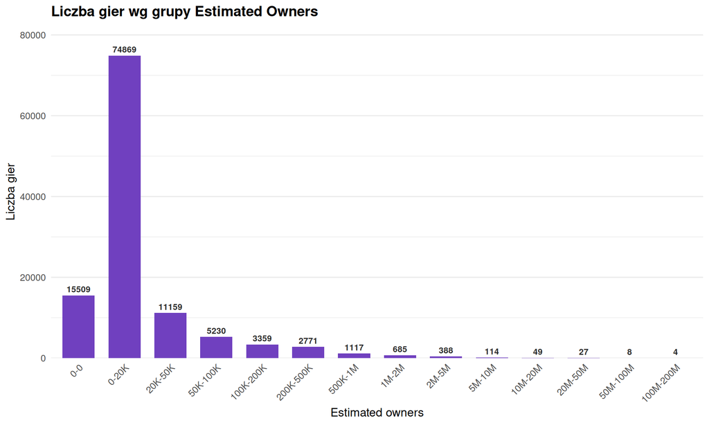

## Najpopularniejsze gry (100M–200M właścicieli)

```
## # A tibble: 4 × 4
##   Name                Estimated_owners      Price Release_date
##   <chr>               <chr>                 <dbl> <date>
## 1 Apex Legends™       100000000 - 200000000     0 2020-11-04
## 2 Counter-Strike 2    100000000 - 200000000     0 2012-08-21
## 3 Dota 2              100000000 - 200000000     0 2013-07-09
## 4 PUBG: BATTLEGROUNDS 100000000 - 200000000     0 2017-12-21
```

> Dokładność klasyfikacji do grup nie wynosi 100% – jest to ograniczenie metody Steam Spy. Akceptujemy ten fakt ze względu na brak lepszej alternatywy.

## Rozkład % pozytywnych recenzji wg grupy właścicieli

```r
steam_violin <- games %>%
  filter(!is.nan(Positive_Percent)) %>%
  mutate(lower_bound = as.numeric(sub("-.*", "", Estimated_owners)),
         Estimated_owners_human = sapply(as.character(Estimated_owners), humanize_owner_est),
         Estimated_owners_human = fct_reorder(Estimated_owners_human, lower_bound))

ownership_stats <- steam_violin %>%
  group_by(Estimated_owners_human) %>%
  summarise(mean_pp = mean(Positive_Percent), median_pp = median(Positive_Percent), .groups = "drop")
```

## Rozkład % pozytywnych recenzji wg grupy właścicieli

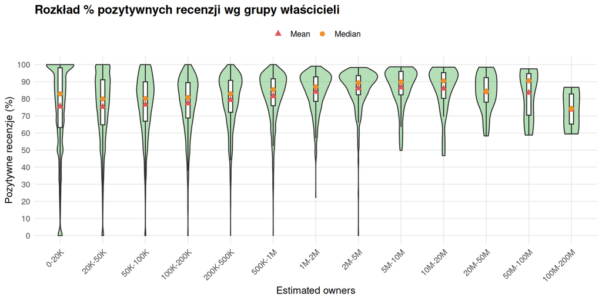

## LIczba gier wędług gatunku

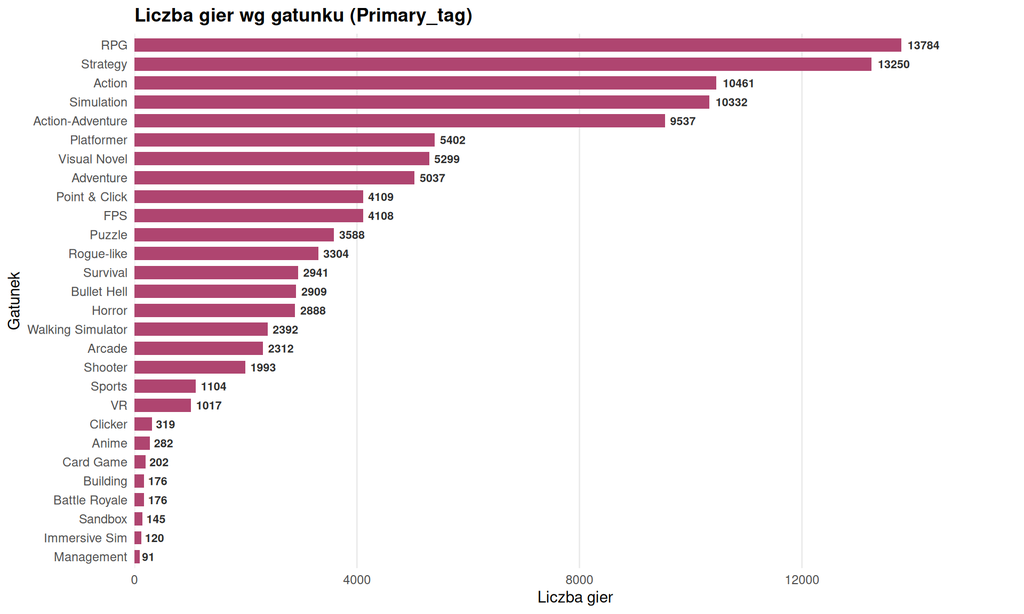

## Liczba gier wydanych w poszczególnych latach

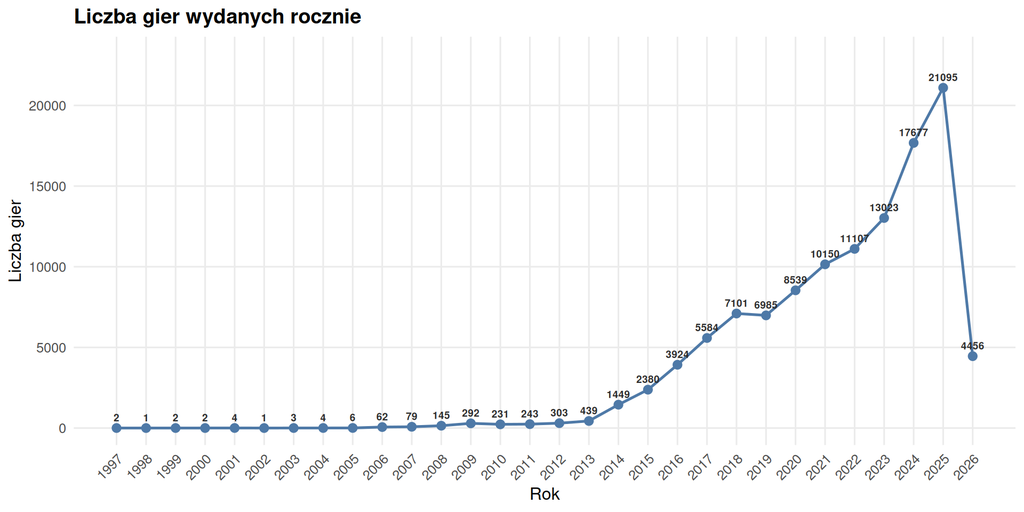

## Regresja trendu czasowego

## Specyfikacja modelu trendu

Przeanalizowano gry wydane w okresie **2011.5 – 2025.5**, pogrupowane według półroczy.

Model dopasowano w przestrzeni **log-log** przy użyciu wielomianu kwadratowego:

\[\log(n\_games) = a + p \cdot \log(t) + q \cdot \log^2(t), \quad t = \text{period} - 2011\]

Po odwróceniu transformacji:

\[n\_games = e^a \cdot (period - 2011)^{p + q \cdot \log(period-2011)}\]

**Uzasadnienie wyboru modelu:**

- Dane wykazują wzrost wykładniczy od 2011 roku
- Transformacja log-log stabilizuje wariancję i linearyzuje zależność
- Wielomian 2. stopnia lepiej opisuje zmieniające się tempo wzrostu niż prosta potęga

## Dopasowanie modelu i przedział ufności

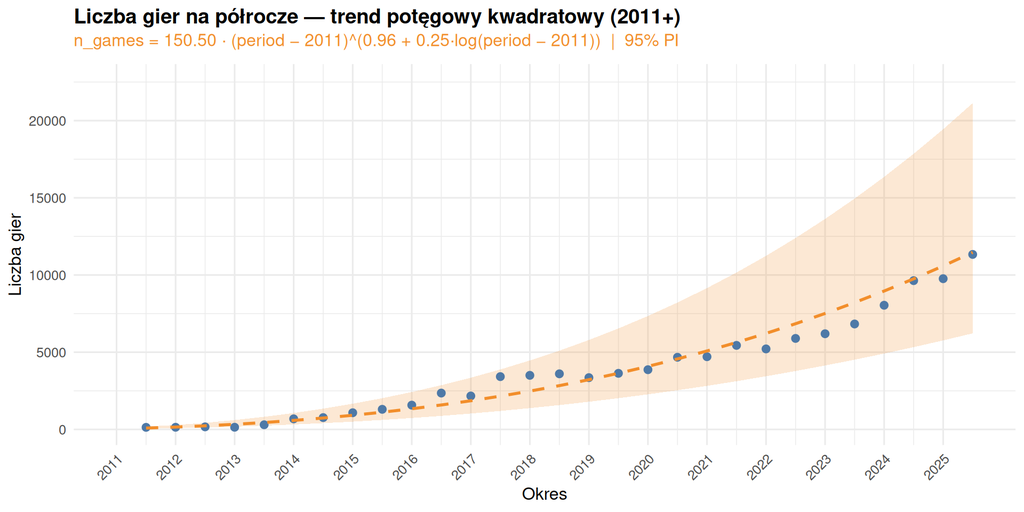

## Wyniki modelu trendu

```
##
## Call:
## lm(formula = log_games ~ log_t + log_t2, data = train_half)
##
## Residuals:
##      Min       1Q   Median       3Q      Max
## -0.86249 -0.10851 -0.01168  0.16208  0.46212
##
## Coefficients:
##             Estimate Std. Error t value Pr(>|t|)
## (Intercept)  5.01394    0.12742  39.351  < 2e-16 ***
## log_t        0.95795    0.16806   5.700 5.35e-06 ***
## log_t2       0.24773    0.06233   3.974    5e-04 ***
## ---
## Signif. codes:  0 '***' 0.001 '**' 0.01 '*' 0.05 '.' 0.1 ' ' 1
##
## Residual standard error: 0.2795 on 26 degrees of freedom
## Multiple R-squared:  0.9619, Adjusted R-squared:  0.959
## F-statistic: 328.5 on 2 and 26 DF,  p-value: < 2.2e-16
```

## Diagnostyka modelu trendu

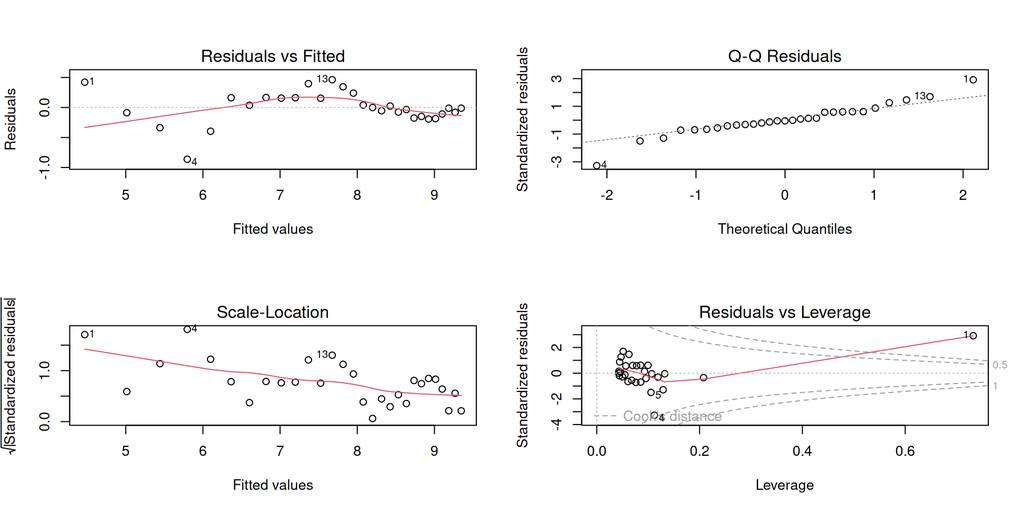

## Ocena dopasowania modelu trendu

**Kluczowe wartości:**

| Miara | Wartość |
| --- | --- |
| R² | 0.962 |
| Adjusted R² | 0.959 |
| Residual SE | 0.2795 (w skali log) |
| F-statistic | 328.5 (p < 2.2e-16) |

Wszystkie współczynniki wysoce istotne (p < 0.001).

## Korelacja wybranych zmiennych

```r
steam_corr <- games %>%
  dplyr::select(Price, Positive_Percent, Median_playtime_forever, Peak_CCU) %>%
  filter(if_all(everything(), ~ !is.nan(.) & !is.infinite(.) & !is.na(.)))

cor_matrix <- cor(steam_corr, method = "spearman")

print(cor_matrix)
```

```
##                              Price Positive_Percent Median_playtime_forever
## Price                   1.00000000       0.03470601              0.24491690
## Positive_Percent        0.03470601       1.00000000             -0.05751577
## Median_playtime_forever 0.24491690      -0.05751577              1.00000000
## Peak_CCU                0.26618755       0.05953534              0.57660665
##                           Peak_CCU
## Price                   0.26618755
## Positive_Percent        0.05953534
## Median_playtime_forever 0.57660665
## Peak_CCU                1.00000000
```

## Macierz korelacji (skala log1p)

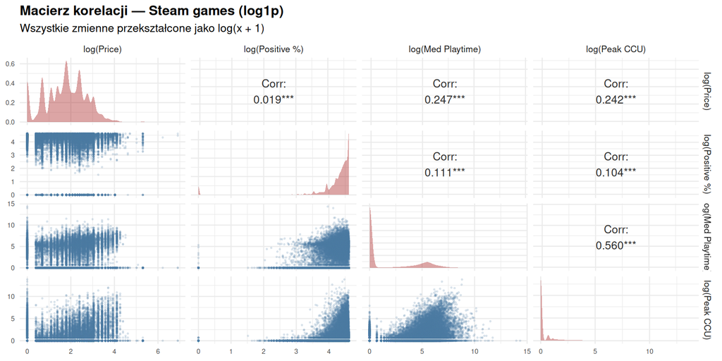

## Wnioski z macierzy korelacji

[output not shown]

**Wniosek:** Na podstawie macierzy jako zmienne objaśniające dla Peak CCU wybrano `Median_playtime_forever` i `Price` — najsilniejsze korelacje z odpowiedzią.

## Regresja wieloraka

## Specyfikacja modelu regresji

Zastosowano **log-liniowy model regresji wielorakiej** (*log-log multiple linear regression*):

\[ \begin{aligned} \log(\text{Peak_CCU}) =\;& \beta_0 + \beta_1 \log(\text{Med_Playtime}) + \beta_2 \log_{1p}(\text{Price}) \\ &+ \beta_3 \cdot \mathbb{1}[\text{Free}] + \sum_k \gamma_k \cdot \mathbb{1}[\text{Genre}_k] + \varepsilon \end{aligned} \]

**Zmienne objaśniające:**

- `log(Median_playtime_forever)` — korelacja 0.560 z Peak CCU
- `log1p(Price)` — korelacja 0.242; `log1p` umożliwia włączenie gier bezpłatnych
- `is_free` — zmienna binarna: model Free-to-Play to odrębna strategia biznesowa
- `Primary_tag` — gatunek jako **factor** (dummy variables), poziom bazowy: **RPG**

## Wyniki modelu regresji — zmienne ilościowe i is_free

```
## Residuals:
```

```
##      0%     25%     50%     75%    100%
## -5.2968 -1.3535 -0.3111  1.0764  9.7800
```

```
##
## Coefficients (continuous + is_free):
```

```
##                    Estimate Std. Error   t value      Pr(>|t|)
## (Intercept)      -1.7142826 0.09400754 -18.23559  2.025737e-73
## log_Med_Playtime  0.4514076 0.01290736  34.97289 1.213859e-256
## log_Price         0.5443073 0.02218827  24.53131 4.581166e-130
## is_freeFree       2.1671404 0.07849803  27.60758 2.821133e-163
```

```
##
## Residual SE: 1.8729  |  R²: 0.2001  |  Adj. R²: 0.1983  |  F: 113.1 (p < 2.2e-16)
```

## Wyniki modelu regresji — współczynniki gatunków

```
##                                 Estimate Std. Error     t value     Pr(>|t|)
## Primary_tagAction-Adventure   0.12751720 0.06816676   1.8706653 6.141300e-02
## Primary_tagFPS                0.69850318 0.07189434   9.7156911 3.054505e-22
## Primary_tagBullet Hell       -0.03315112 0.10586827  -0.3131356 7.541825e-01
## Primary_tagRogue-like         0.04692463 0.08006489   0.5860825 5.578298e-01
## Primary_tagVisual Novel      -0.74756575 0.07330862 -10.1975156 2.489702e-24
## Primary_tagWalking Simulator -0.36898545 0.10844403  -3.4025427 6.695483e-04
## Primary_tagPoint & Click     -0.33166120 0.08140692  -4.0741158 4.645229e-05
## Primary_tagSurvival           0.65828742 0.08122277   8.1047157 5.736827e-16
## Primary_tagHorror             0.01466721 0.10033815   0.1461778 8.837832e-01
## Primary_tagPlatformer        -0.32592092 0.08891840  -3.6653936 2.479008e-04
## Primary_tagShooter            0.52253614 0.12151210   4.3002806 1.717745e-05
## Primary_tagBattle Royale     -0.45348805 0.40170290  -1.1289141 2.589540e-01
## Primary_tagStrategy           0.12871274 0.06136545   2.0974790 3.596966e-02
## Primary_tagSimulation         0.10912935 0.07061648   1.5453808 1.222775e-01
## Primary_tagClicker           -0.34839509 0.33436518  -1.0419598 2.974489e-01
## Primary_tagImmersive Sim     -0.67569694 0.52122076  -1.2963738 1.948688e-01
## Primary_tagManagement        -0.06218132 0.56643473  -0.1097767 9.125881e-01
## Primary_tagBuilding           0.12773556 0.33381629   0.3826523 7.019836e-01
## Primary_tagSandbox            0.20534562 0.31089561   0.6604970 5.089462e-01
## Primary_tagPuzzle            -0.45081239 0.12050091  -3.7411534 1.839325e-04
## Primary_tagCard Game         -0.85709787 0.50255233  -1.7054898 8.812601e-02
## Primary_tagArcade            -0.01354434 0.13019877  -0.1040282 9.171485e-01
## Primary_tagSports            -0.48134836 0.28906787  -1.6651742 9.590110e-02
## Primary_tagAnime             -0.26776311 0.23128855  -1.1577015 2.470063e-01
## Primary_tagVR                -1.49151848 0.33525300  -4.4489341 8.698457e-06
## Primary_tagAction            -0.62474537 0.13872455  -4.5034954 6.740251e-06
## Primary_tagAdventure         -0.52600684 0.15845047  -3.3196924 9.035427e-04
```

## Diagnostyka modelu regresji

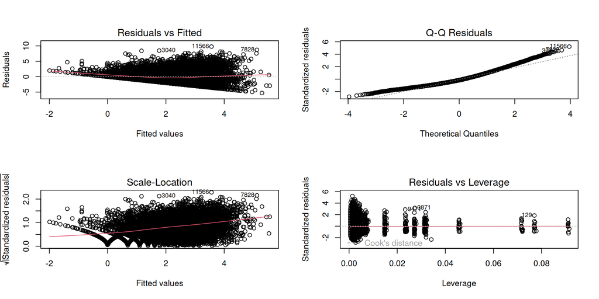

## Wzór modelu i efekty gatunków

```
## Wzór w przestrzeni logarytmicznej
```

```
## log(Peak_CCU) = -1.7143 + 0.4514 * log(Med_Playtime) + 0.5443 * log1p(Price) + 2.1671 * is_free  +  γ_genre
```

```
## Wzór po odwróceniu transformacji
```

[output not shown]

```
## Mnożniki gatunkowe względem RPG
```

```
##              Genre   gamma multiplier
##                FPS  0.6985     2.0107
##           Survival  0.6583     1.9315
##            Shooter  0.5225     1.6863
##            Sandbox  0.2053     1.2279
##           Strategy  0.1287     1.1374
##           Building  0.1277     1.1363
##   Action-Adventure  0.1275     1.1360
##         Simulation  0.1091     1.1153
##         Rogue-like  0.0469     1.0480
##             Horror  0.0147     1.0148
##             Arcade -0.0135     0.9865
##        Bullet Hell -0.0332     0.9674
##         Management -0.0622     0.9397
##              Anime -0.2678     0.7651
##         Platformer -0.3259     0.7219
##      Point & Click -0.3317     0.7177
##            Clicker -0.3484     0.7058
##  Walking Simulator -0.3690     0.6914
##             Puzzle -0.4508     0.6371
##      Battle Royale -0.4535     0.6354
##             Sports -0.4813     0.6179
##          Adventure -0.5260     0.5910
##             Action -0.6247     0.5354
##      Immersive Sim -0.6757     0.5088
##       Visual Novel -0.7476     0.4735
##          Card Game -0.8571     0.4244
##                 VR -1.4915     0.2250
```

## Ocena modelu regresji

**Założenia LINE:**

- **Liniowość:** trójkątny kształt reszt — asymetria strukturalna, model nie opisuje w pełni ogona prawego
- **Niezależność:** gry traktowane jako niezależne obserwacje — założenie prawdopodobnie spełnione
- **Normalność:** Q-Q z ciężkim prawym ogonem — megahity (CS:GO, Dota 2) jako ekstrema
- **Homoskedastyczność:** Scale-Location wykazuje rosnący trend — **heteroskedastyczność**

## **Kluczowe wartości:**

| Miara | Wartość | Interpretacja |
| --- | --- | --- |
| R² | 0.200 | Model wyjaśnia 20% wariancji Peak CCU |
| Residual SE | 1.873 (log) | Typowy błąd ≈ \(e^{1.873}\) ≈ **6.5×** na oryginalnej skali |
| F-statistic | 113.1 (p < 2.2e-16) | Model istotnie lepszy niż sama średnia |
| `is_freeFree` | **+2.167*** | Gry F2P mają ~**8.7×** wyższy Peak CCU niż płatne |

**Wniosek:** Model poprawnie identyfikuje kierunki zależności, lecz jego zdolność predykcyjna jest ograniczona. Popularność gry zależy w dużej mierze od czynników nieobecnych w danych — budżetu marketingowego, marki wydawcy, momentu premiery.

## Cena a gatunek

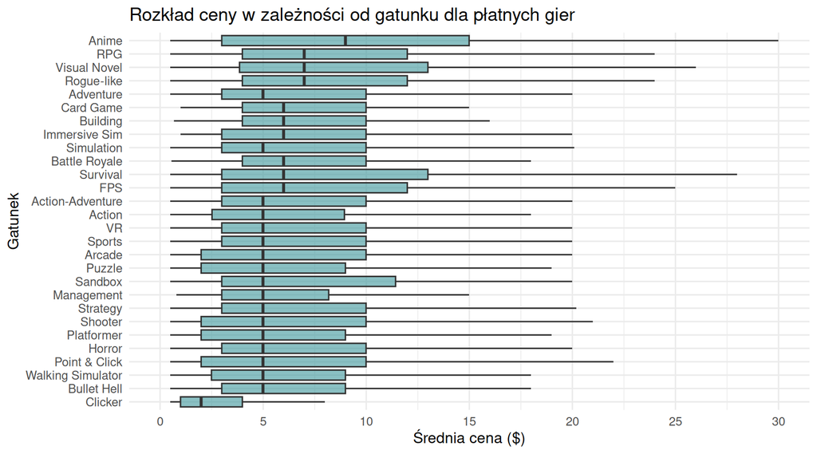

## Cena a gatunek: test Kruskala-Wallisa

- **H₀:** rozkład `Price` jest identyczny we wszystkich grupach `Primary_tag`
- **H₁:** co najmniej jedna grupa ma inny rozkład cen niż pozostałe

```r
kruskal.test(Price ~ Primary_tag, data = games)
```

```
##
##  Kruskal-Wallis rank sum test
##
## data:  Price by Primary_tag
## Kruskal-Wallis chi-squared = 2861.2, df = 27, p-value < 2.2e-16
```

**Odrzucamy H₀**. Ceny gier różnią się istotnie statystycznie między gatunkami.

## Wyznaczanie typu gry na podstawie `Categories`

```r
# Create a new dataframe with game type classification
games_sp_or_mp <- games %>%
  mutate(
    # Detect category presence
    has_single = str_detect(Categories, "Single-player"),
    has_multi = str_detect(Categories, "Multi-player"),

    # Assign type based on category combination
    Type = case_when(
      has_single & has_multi ~ "Both",
      has_single ~ "Single-player",
      has_multi ~ "Multi-player",
      TRUE ~ NA_character_
    )
  ) %>% dplyr::select( # Select relevant columns
    Name,
    Peak_CCU,
    Median_playtime_forever,
    Estimated_owners,
    Type
  ) %>%
   mutate(
    Lower_bound = as.numeric(sub("-.*", "", Estimated_owners)),
    Estimated_owners = sapply(as.character(Estimated_owners), humanize_owner_est)
   )
```

## Bardzo dobry coverage

```
## Games with unknown type: 154
```

```
## Coverage: 99.9 %
```

## Wilcoxon rank-sum test (`Peak_CCU` vs typ gry)

- **H₀:** Rozkład Peak_CCU jest taki sam dla gier singleplayer i multiplayer.
- **H₁:** Rozkład Peak_CCU różni się pomiędzy typami gier .

```r
# Wilcoxon test comparing Peak CCU between Single-player and Multi-player only
wilcox_peak <- games_sp_or_mp %>%
  filter(Type %in% c("Single-player", "Multi-player")) %>%
  wilcox.test(Peak_CCU ~ Type, data = .)

# Print test results
print(wilcox_peak)
```

```
##
##  Wilcoxon rank sum test with continuity correction
##
## data:  Peak_CCU by Type
## W = 219936864, p-value = 4.634e-10
## alternative hypothesis: true location shift is not equal to 0
```

Wynik testu wskazuje **na istotną statystycznie różnicę** w medianie `Peak_CCU` pomiędzy typami gier (p < 0.001)

## Potwierdzenie przez wizualizację

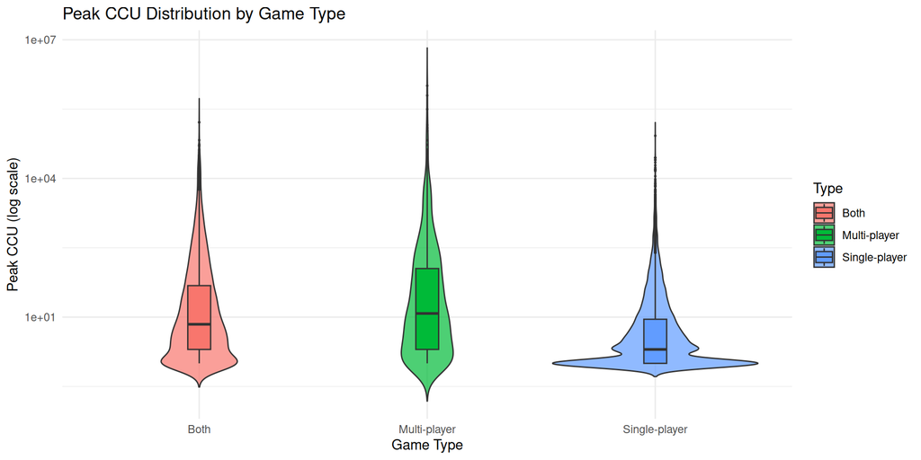

## Wilcoxon rank-sum test (`Median_playtime_forever` vs typ gry)

- **H₀:** Rozkład medianowego czasu gry jest taki sam dla gier singleplayer i multiplayer.
- **H₁:** Rozkład medianowego czasu gry różni się pomiędzy typami gier.

```r
# Wilcoxon test comparing Peak CCU between Single-player and Multi-player only
wilcox_med <- games_sp_or_mp %>%
  filter(Type %in% c("Single-player", "Multi-player")) %>%
  wilcox.test(Median_playtime_forever ~ Type, data = .)

# Print test results
print(wilcox_med)
```

```
##
##  Wilcoxon rank sum test with continuity correction
##
## data:  Median_playtime_forever by Type
## W = 214102340, p-value = 0.2995
## alternative hypothesis: true location shift is not equal to 0
```

Nie stwierdzono istotnej statystycznie różnicy w medianie czasu gry pomiędzy typami (p = 0.2995). Sugeruje to, że typ gry **nie wpływa istotnie** na przeciętny czas gry.

## Potwierdzenie przez wizualizację

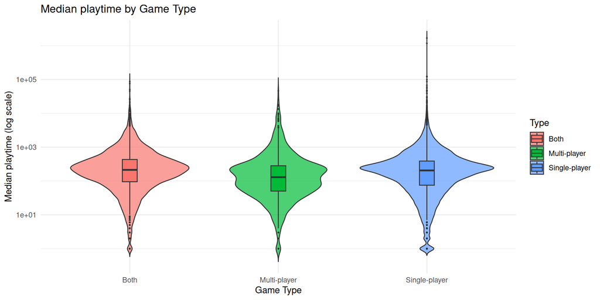

## Test chi-kwadrat (Estimated owners vs typ gry))

```r
# Chi-square test for association between game Type and Estimated Owners distribution
owners_type_table <- games_sp_or_mp %>%
  filter(!is.na(Type), !is.na(Estimated_owners)) %>%
  count(Type, Estimated_owners) %>%
  tidyr::pivot_wider(
    names_from = Estimated_owners,
    values_from = n,
    values_fill = 0
  )

# Convert to contingency table
owners_matrix <- owners_type_table %>%
  column_to_rownames("Type") %>%
  as.matrix()
```

## Wyniki testu

- **H₀:** Typ gry (singleplayer/multiplayer/both) i kategoria liczby właścicieli są niezależne.
- **H₁:** Istnieje zależność pomiędzy typem gry a kategorią liczby właścicieli.

```r
# Perform chi-square test
chi_owners <- chisq.test(owners_matrix)

# Print results
print(chi_owners)
```

```
##
##  Pearson's Chi-squared test
##
## data:  owners_matrix
## X-squared = 4180.8, df = 26, p-value < 2.2e-16
```

Wykazano istotną zależność pomiędzy typem gry a kategorią liczby właścicieli (p < 0.001). Oznacza to, że rozkład liczby właścicieli **różni się** w zależności od typu gry.

## Kolejne sortowanie

```r
# Order Estimated_owners properly
owner_levels <- games_sp_or_mp %>%
  arrange(Lower_bound) %>%
  distinct(Estimated_owners, Lower_bound) %>%
  pull(Estimated_owners)

games_sp_or_mp <- games_sp_or_mp %>%
  mutate(
    Estimated_owners = factor(
      Estimated_owners,
      levels = owner_levels,
      ordered = TRUE
    )
  )
```

## Porównywanie rozkładów `Estimated Owners` vs typ gry

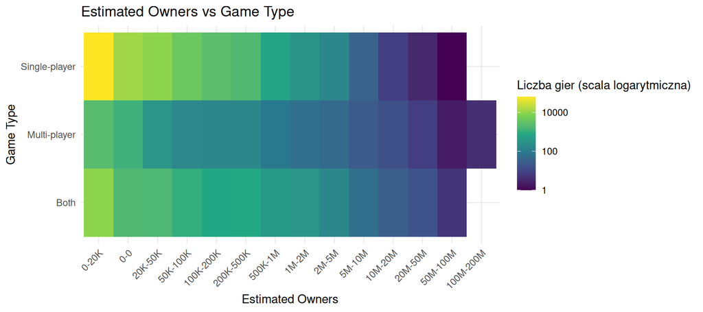

## Porównywanie ocen w Steam vs na Metacritic

## Usuwanie gier bez opinii

Usuwamy najpierw gry, które nie mają żadnych recenzji w Steam, potem te z zerową oceną na Metacritic.

W tym datasecie nie ma różnicy między oceną 0 na Metacritic a jej brakiem. Zakładamy, że szansza na uzyskanie przez jakkolwiek słabą grę prawdziwej oceny 0 jest bardzo mała, zatem usuwanie jedynie kilku takich gier gdyby istniały nie zmieniło by znacząco wyniku.

```r
initial_n <- nrow(games)

# Remove NA in Positive_Percent
games_opinion_clean <- games %>%
  filter(!is.na(Positive_Percent))

removed_na <- initial_n - nrow(games_opinion_clean)

# Remove Metacritic_score == 0 (treated as missing)
games_opinion_clean <- games_opinion_clean %>%
  filter(Metacritic_score != 0)

removed_meta0 <- initial_n - removed_na - nrow(games_opinion_clean)

final_n <- nrow(games_opinion_clean)
```

## Usuwanie gier bez opinii

Bardzo wiele gier nie ma oceny na Metacritic.

```
## Initial observations: 115289
```

```
## Removed NA Positive_Percent: 34699 ( 30.1 % )
```

```
## Removed Metacritic = 0: 76575 ( 66.42 % )
```

```
## Final dataset size: 4015 ( 3.48 % )
```

## Korelacja Spearmana

```r
# Spearman correlation
spearman_test <- cor.test(
  games_opinion_clean$Positive_Percent,
  games_opinion_clean$Metacritic_score,
  method = "spearman"
)
print(spearman_test)
```

```
##
##  Spearman's rank correlation rho
##
## data:  games_opinion_clean$Positive_Percent and games_opinion_clean$Metacritic_score
## S = 4488563660, p-value < 2.2e-16
## alternative hypothesis: true rho is not equal to 0
## sample estimates:
##       rho
## 0.5838959
```

## Korelacja Pearsona

```r
# Pearson correlation
pearson_test <- cor.test(
  games_opinion_clean$Positive_Percent,
  games_opinion_clean$Metacritic_score,
  method = "pearson"
)
print(pearson_test)
```

```
##
##  Pearson's product-moment correlation
##
## data:  games_opinion_clean$Positive_Percent and games_opinion_clean$Metacritic_score
## t = 47.272, df = 4013, p-value < 2.2e-16
## alternative hypothesis: true correlation is not equal to 0
## 95 percent confidence interval:
##  0.5778199 0.6175719
## sample estimates:
##       cor
## 0.5980636
```

## Podsumowanie dla 2 metod korelacji

Wyniki wskazują na umiarkowaną dodatnią korelację między ocenami graczy a ocenami krytyków. Zarówno współczynnik Pearsona (r ≈ 0.60), jak i Spearmana (ρ ≈ 0.58) są statystycznie istotne, co oznacza, że wyższe oceny Metacritic zazwyczaj odpowiadają wyższemu odsetkowi pozytywnych recenzji graczy.

Nie jest to korelacja idealna, ewidentnie gracze i krytycy nie zawsze są zgodni.

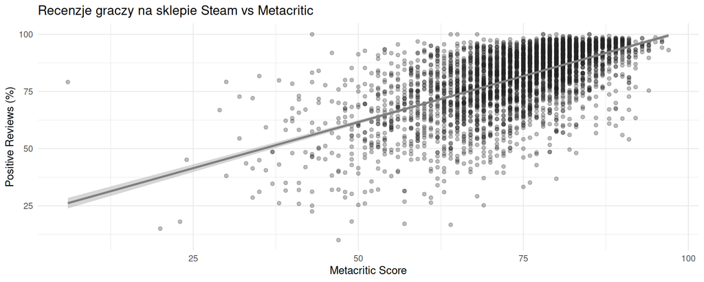

## Cena

## Rozkład ceny

```
##     Min.  1st Qu.   Median     Mean  3rd Qu.     Max.
##    0.000    0.990    4.990    7.084    9.990  999.980
```

Chcemy zbadać, z jakiego rozkładu pochodzą ceny. Zacznijmy od histogramu, aby spróbować zgadnąć, jaki rozkład może mieć nasza zmienna.

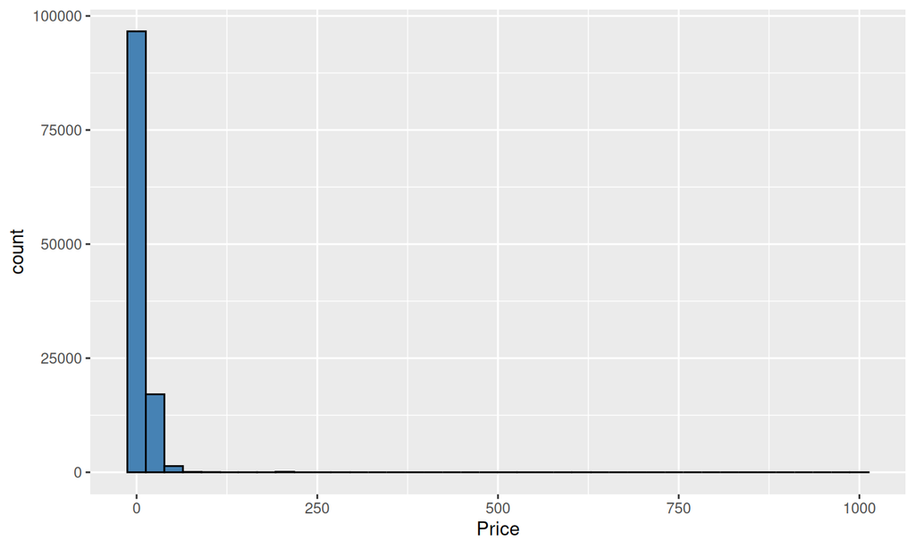

## Skala logarytmiczna

Widzimy, że na tym etapie nie otrzymujemy zbyt wielu informacji. Spróbujmy więc innego podejścia. Wiemy, że większość gier kosztuje od $0 do $100. Użyjmy skali logarytmicznej (\(\log_{10}\)), aby wartości $1, $10 i $100 były w równej odległości od siebie – dzięki temu lepiej zobaczymy strukturę danych. Wykorzystamy funkcję \(log1p\), która liczy \(\log(1+x)\), ponieważ w zbiorze mamy gry darmowe ($0).

## Wykres logarytmiczny

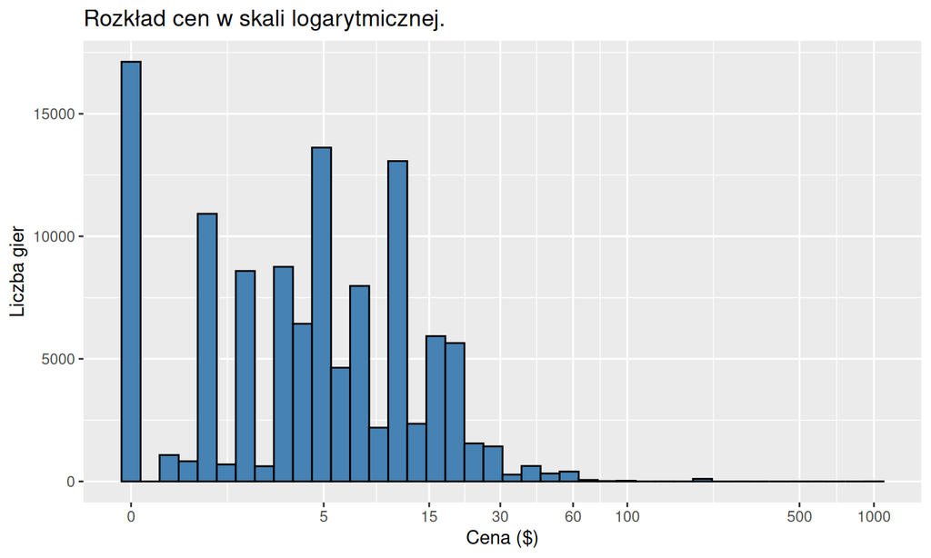

## Wykres logarytmiczny

Widzimy, że w skali logarytmicznej (po usunięciu gier bezpłatnych) rozkład cen przypomina rozkład normalny. Skoro dzieje się to w skali logarytmicznej, najprawdopodobniej mamy do czynienia z rozkładem log-normalnym. Dysponujemy dużym zbiorem danych (115 tys. obserwacji), więc aby sprawdzić naszą hipotezę, najlepiej będzie użyć wykresu kwantylowego (Q-Q plot). W tym celu zlogarytmujemy ceny i sporządzimy odpowiednie wykresy.

Przed tym możemy zrobić testy normalności. Test Shapiro nie zadziała bo mamy >5000 próbek. Test Kolmogorova-Smirnova pokazuje nam

```r
ks.test(games$Price, "plnorm")
```

```
##
##  Asymptotic one-sample Kolmogorov-Smirnov test
##
## data:  games$Price
## D = 0.517, p-value < 2.2e-16
## alternative hypothesis: two-sided
```

Co prawda, mamy duzą liczbę próbek, więc dla tego mamy taki niski p-value.

## Wykres kwantylowy

```r
paid_games <- games %>%
  filter(Price > 0) %>%
  mutate(log_price = log10(Price))
```

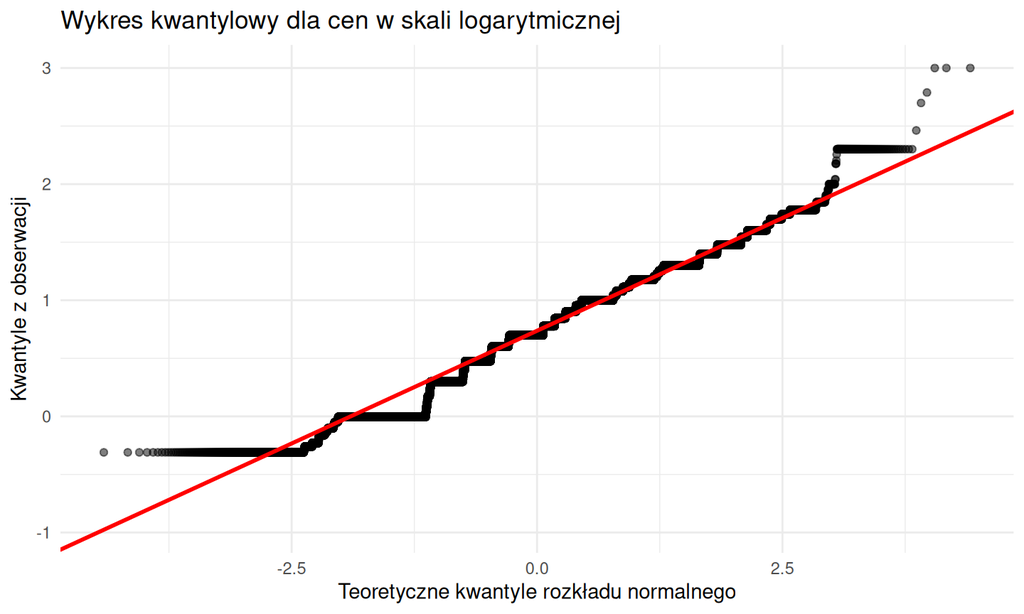

## Wykres kwantylowy

Widzimy, że prosta idealnie pokrywa się z danymi, poza samymi „ogonami”. Te ogony to bardzo niskie ceny (poniżej $1) oraz bardzo wysokie ($200–$1000). Te ostatnie nie są aż tak istotne, ponieważ niewielu deweloperów decyduje się na ustawienie tak wysokiej ceny.

Porównajmy wykresy kwantylowe z innymi rozkładami, aby upewnić się, że to dopasowanie jest najlepsze. Dobrym kandydatem jest rozkład Weibulla, który jest zbliżony do rozkładów gamma i log-normalnego. Wykorzystamy do tego bibliotekę \(fitdistrplus\).

## Wykres kwantylowy

```r
library(fitdistrplus)
library(patchwork)    # Przygotowanie kilku wykresów

# Usuwamy gry bezpłatne.
# 115k obserwacji to za dużo na test – do analizy wystarczy 20k
plot_data <- games %>% filter(Price > 0) %>% sample_n(20000)
prices <- plot_data$Price

# Estymujemy parametry różnych rozkładów.
fit_norm   <- fitdist(prices, "norm")
fit_lnorm   <- fitdist(prices, "lnorm")
fit_gamma   <- fitdist(prices, "gamma")
fit_weibull <- fitdist(prices, "weibull")
```

## Wykres kwantylowy

```r
# Funkcja pomocnicza do tworzenia wykresów kwantylowych
make_qq_plot <- function(data, dist_name, q_func, params, title, aic_val) {
  ggplot(data.frame(price = data), aes(sample = price)) +
    stat_qq(distribution = q_func, dparams = params, alpha = 0.5) +
    stat_qq_line(distribution = q_func, dparams = params, color = "red") +
    labs(title = title, subtitle= paste("AIC: ", round(aic_val, 2)),
         x = "Theoretical", y = "Actual") +
    theme_minimal()
}
# Tworzymy cztery wykresy
p_norm <- make_qq_plot(prices, "norm", qnorm,
                       list(mean = mean(prices), sd = sd(prices)), "Normal Dist",
                       fit_norm$aic)

p_log  <- make_qq_plot(prices, "lnorm", qlnorm,
                       as.list(fit_lnorm$estimate), "Log-Normal Dist",
                       fit_lnorm$aic)

p_gamma <- make_qq_plot(prices, "gamma", qgamma,
                        as.list(fit_gamma$estimate), "Gamma Dist",
                        fit_gamma$aic)

p_weib <- make_qq_plot(prices, "weibull", qweibull,
                       as.list(fit_weibull$estimate), "Weibull Dist",
                       fit_weibull$aic)
```

## Wykres kwantylowy

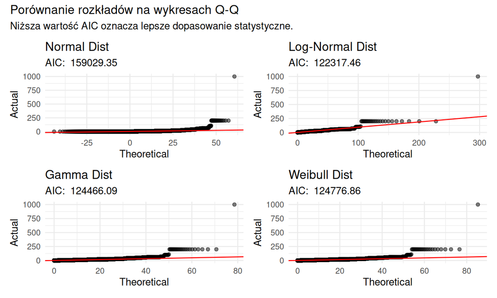

## Wykres kwantylowy

Jak widać, model log-normalny dobrze przewiduje ceny w zakresie $1–$100. Stwórzmy więc wykres gęstości, estymując parametry naszego rozkładu metodą największej wiarygodności (MLE).

```r
# Estymacja parametrów
mean_log <- mean(paid_games$log_price)
sd_log <- sd(paid_games$log_price)
```

## Gęstość rozkładu cen

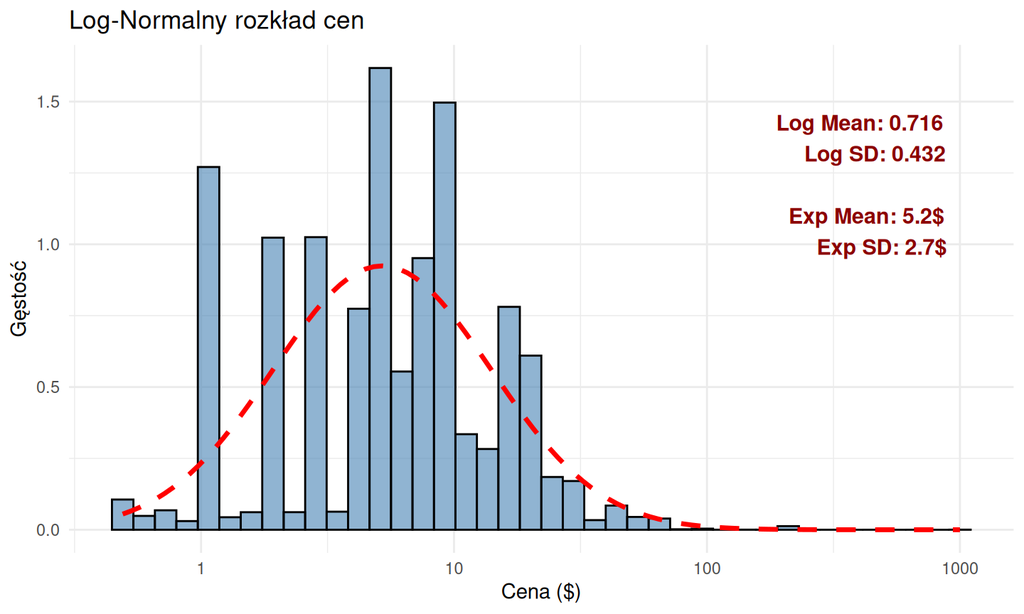

## Gęstość rozkładu cen

Dane wykazują tendencję do dopasowania do rozkładu log-normalnego. Pamiętajmy jednak, że ceny nie zmieniają się w sposób ciągły – widzimy wyraźne skoki przy najpopularniejszych wartościach ($0.99, $4.99, $9.99 itd.)

Zobaczmy podstawowe statystyki na wykresie.

```r
# Mean, median, mode
mean_val   <- mean(paid_games$Price, na.rm = TRUE)
median_val <- median(paid_games$Price, na.rm = TRUE)
dens <- density(paid_games$Price, adjust=0.5)
mode_val <- dens$x[which.max(dens$y)]

vlines <- data.frame(
  stats = c("Mean", "Median", "Mode"),
  values = c(mean_val, median_val, mode_val),
  color = c("red", "blue", "darkgreen")
)
```

## Gęstość rozkładu cen

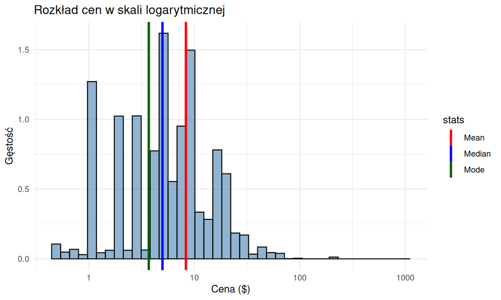

## Dystrybuanta rozkładu

Przez te skoki (punkty skupienia) trudniej zauważyć, że cena faktycznie ma rozkład log-normalny. Możemy jednak porównać dystrybuantę naszych danych z dystrybuantą teoretyczną.

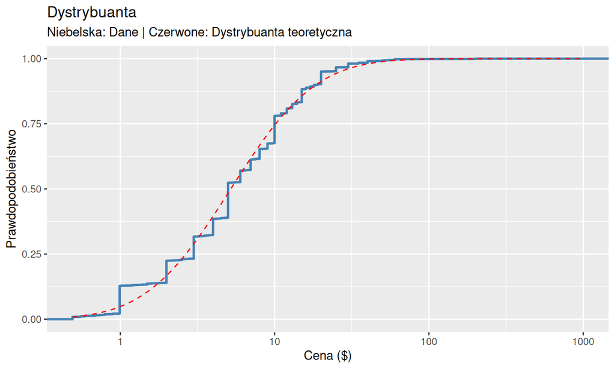

## Dystrybuanta rozkładu

Widzimy bardzo dobre dopasowanie. Widać również skoki przy najpopularniejszych cenach ($1, $5, $7, $10). Ponieważ liczba obserwacji jest bardzo duża (115 tys.), wyznaczanie przedziałów ufności nie ma większego sensu – przy takiej skali zaczyna działać prawo wielkich liczb i przedziały byłyby ekstremalnie wąskie.

```
## BOOTSTRAP CONFIDENCE INTERVAL CALCULATIONS
## Based on 1000 bootstrap replicates
##
## CALL :
## boot.ci(boot.out = boot_results, type = "perc")
##
## Intervals :
## Level     Percentile
## 95%   ( 8.242,  8.406 )
## Calculations and Intervals on Original Scale
```

## Liczba rekomendacji

## Czy istnieje związek z ceną?

```
##
## Call:
## lm(formula = Recommendations ~ Price, data = paid_games)
##
## Residuals:
##     Min      1Q  Median      3Q     Max
## -106542   -1166    -634    -315 1199208
##
## Coefficients:
##             Estimate Std. Error t value Pr(>|t|)
## (Intercept)  102.931     55.595   1.851   0.0641 .
## Price        106.441      3.781  28.152   <2e-16 ***
## ---
## Signif. codes:  0 '***' 0.001 '**' 0.01 '*' 0.05 '.' 0.1 ' ' 1
##
## Residual standard error: 14360 on 98168 degrees of freedom
## Multiple R-squared:  0.008008,   Adjusted R-squared:  0.007998
## F-statistic: 792.5 on 1 and 98168 DF,  p-value: < 2.2e-16
```

## Czy istnieje związek z ceną?

W skali logarytmicznej

```
##
## Call:
## lm(formula = log1p(Recommendations) ~ log1p(Price), data = paid_games)
##
## Residuals:
##     Min      1Q  Median      3Q     Max
## -6.7808 -1.6706 -1.0323 -0.0354 12.1345
##
## Coefficients:
##              Estimate Std. Error t value Pr(>|t|)
## (Intercept)  -0.71080    0.02125  -33.46   <2e-16 ***
## log1p(Price)  1.08437    0.01035  104.81   <2e-16 ***
## ---
## Signif. codes:  0 '***' 0.001 '**' 0.01 '*' 0.05 '.' 0.1 ' ' 1
##
## Residual standard error: 2.568 on 98168 degrees of freedom
## Multiple R-squared:  0.1006, Adjusted R-squared:  0.1006
## F-statistic: 1.099e+04 on 1 and 98168 DF,  p-value: < 2.2e-16
```

\(e^{2.56} \approx 13\)

## Czy istnieje związek z ceną?

```r
price_breaks <- c(0, 5, 10, 20, 40, 60, 100, 1000)
price_labels <- c("$0-$5", "$5-$10", "$10-$20", "$20-$40", "$40-$60", "$60-$100", "$100-$1000")

# Stosujemy średnią rekomendacji do grupy
price_analysis <- games %>%
  mutate(price_tier = cut(Price,
                          breaks = price_breaks,
                          labels = price_labels,
                          include.lowest = TRUE)) %>%
  group_by(price_tier) %>%
  summarise(
    avg_recs = mean(Recommendations, na.rm = TRUE),
    game_count = n()
  )
```

```
## # A tibble: 7 × 3
##   price_tier avg_recs game_count
##   <fct>         <dbl>      <int>
## 1 $0-$5          336.      68529
## 2 $5-$10         682.      25207
## 3 $10-$20       1706.      16686
## 4 $20-$40       6291.       3917
## 5 $40-$60      18249.        729
## 6 $60-$100     11942.        103
## 7 $100-$1000       0         118
```

## Liczba właściceli

## Liczba właściceli

Mamy kolumnę `Owner factor`, która zawiera szacowaną liczbę właścicieli gier. Możemy przeprowadzić analizę opisową tej statystyki.

```r
library(tidyverse)

# 1. Expand Categories (One row per game per category)
games_clean <- games %>%
  mutate(category_list = strsplit(as.character(Categories), ",")) %>%
  unnest(category_list) %>%
  mutate(category_list = trimws(category_list)) # Remove accidental spaces

# 2. Fix Owner Ranges (Making them an ordered factor)
# This prevents R from sorting them alphabetically (like "100k" before "20k")
raw_levels <- c(
  "0 - 0", "0 - 20000", "20000 - 50000", "50000 - 100000",
  "100000 - 200000", "200000 - 500000", "500000 - 1000000",
  "1000000 - 2000000", "2000000 - 5000000", "5000000 - 10000000",
  "10000000 - 20000000", "20000000 - 50000000", "50000000 - 100000000",
  "100000000 - 200000000", "200000000 - 500000000", "500000000 - 1000000000",
  "1000000000 - 2000000000"
)
```

## Liczba właściceli

```r
# 3. Function to turn "1000000 - 2000000" into "1M - 2M"
format_short_range <- function(x) {
  sapply(x, function(s) {
    if (s == "0 - 0") return("0")
    # Split the range, convert to numeric
    nums <- as.numeric(unlist(strsplit(s, " - ")))
    # Format using short scale (K, M, B)
    formatted <- label_number(scale_cut = cut_short_scale())(nums)
    # Join them back together
    paste(formatted, collapse = " - ")
  })
}

clean_labels_short <- format_short_range(raw_levels)

# 4. Apply to the data
games_clean <- games_clean %>%
  mutate(Owners_Factor = factor(Estimated_owners,
                                levels = raw_levels,
                                labels = clean_labels_short,
                                ordered = TRUE))
```

## Liczba właściceli

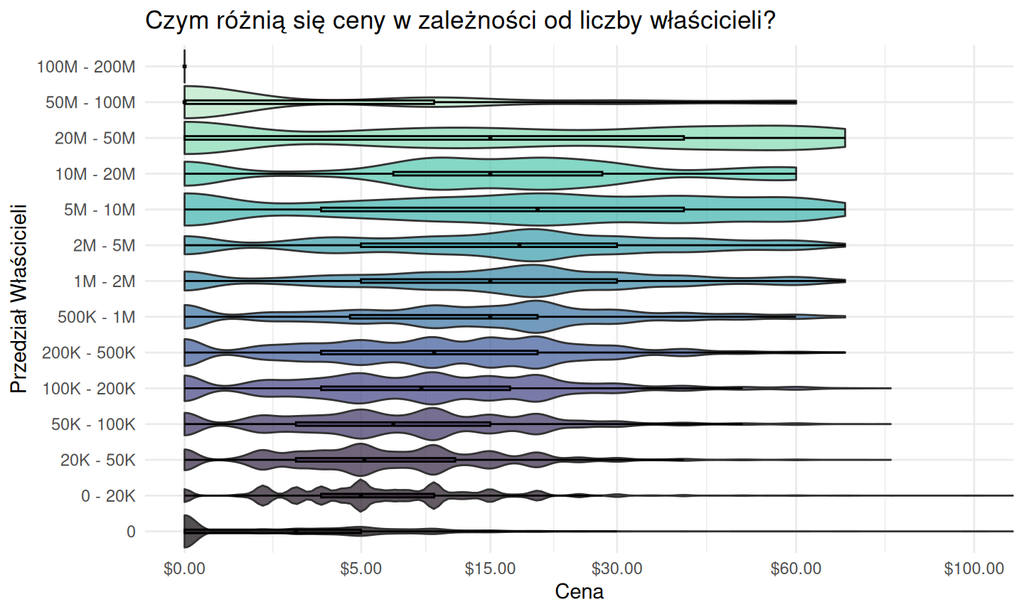

## Liczba właściceli

```r
kruskal.test(Price ~ Owners_Factor, data = games_clean)
```

```
##
##  Kruskal-Wallis rank sum test
##
## data:  Price by Owners_Factor
## Kruskal-Wallis chi-squared = 45524, df = 13, p-value < 2.2e-16
```

Chi kwadrat jest duże, więc rozkłady są różne. W rzeczywistości otrzymujemy tak niską wartość p-value głównie ze względu na bardzo dużą liczbę obserwacji. Stwórzmy mapę ciepła (heatmap), aby sprawdzić, czy faktycznie istnieje tam jakakolwiek zależność.

## Liczba właściceli

Podział gier na grupy.

```r
games_analysis <- games_clean %>%
  mutate(Price_Tier = cut(Price,
                          breaks = c(-1, 0, 5, 15, 30, Inf),
                          labels = c("Free", "Budget (<$5)",
                                     "Mid ($5-$15)", "Standard ($15-$30)",
                                     "Premium (>$30)")))

prop_table <- prop.table(table(games_analysis$Price_Tier, droplevels(games_analysis$Owners_Factor)), margin = 2)
```

## Liczba właściceli

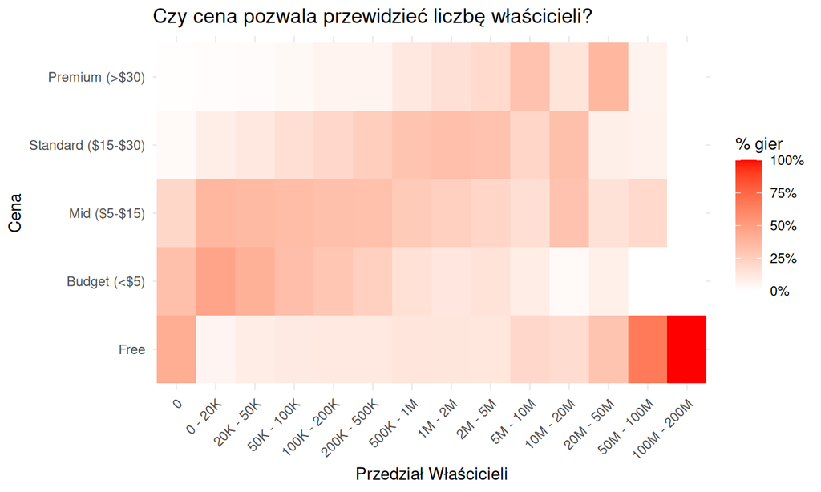

## Kategorie gier

## Kategorie gier

```r
category_price_relation <- games_clean %>%
  filter(Price > 0) %>%
  group_by(category_list) %>%
  summarise(
    median_price = median(Price),
    count = n()
  ) %>%
  filter(count > 100) %>% # Ignore rare categories
  arrange(desc(median_price))

max_y <- ceiling(max(category_price_relation$median_price))
```

## Kategorie gier

[figure not shown]

## Kategorie gier

```r
kruskal.test(Price ~ category_list, data = games_clean)
```

```
##
##  Kruskal-Wallis rank sum test
##
## data:  Price by category_list
## Kruskal-Wallis chi-squared = 54938, df = 127, p-value < 2.2e-16
```

## Publishers

## Publishers

Analiza czołowych wydawców gier

```r
top_publishers <- games_clean %>%
  count(Publishers, sort = TRUE) %>%
  slice(1:15) %>%
  pull(Publishers)
```

Ten kod zlicza, jak często występuje dany wydawca.

## Publishers

Wymagane jest dodatkowe formatowanie danych.

```r
library(tidyverse)

# 1. Define the cleaning pattern
# This looks for common suffixes, case-insensitive, with or without dots
legal_suffixes <- "\\b(Inc|INC|LLC|Llc|Ltd|LTD|Corp|Corporation|S.L|S.A|Co|GmbH|Co., Ltd|Co., Ltd.)[.]?\\b"

publishers_clean <- paid_games %>%
  filter(!is.na(Publishers), Publishers != "") %>%
  # Separate co-publishers first
  mutate(publisher_list = strsplit(as.character(Publishers), ",")) %>%
  unnest(publisher_list) %>%
  # Clean up the names
  mutate(
    publisher_list = trimws(publisher_list),
    # Remove legal suffixes
    publisher_list = str_remove_all(publisher_list, legal_suffixes),
    # Remove any trailing commas or dots left behind
    publisher_list = str_remove_all(publisher_list, "[.,]$"),
    # Final trim to catch new spaces created by removals
    publisher_list = trimws(publisher_list)
  ) %>%
  filter(publisher_list != "") # Remove any that became empty after cleaning
```

## Publishers

```r
top_20_publishers <- publishers_clean %>%
  count(publisher_list, sort = TRUE) %>%
  head(20)
```

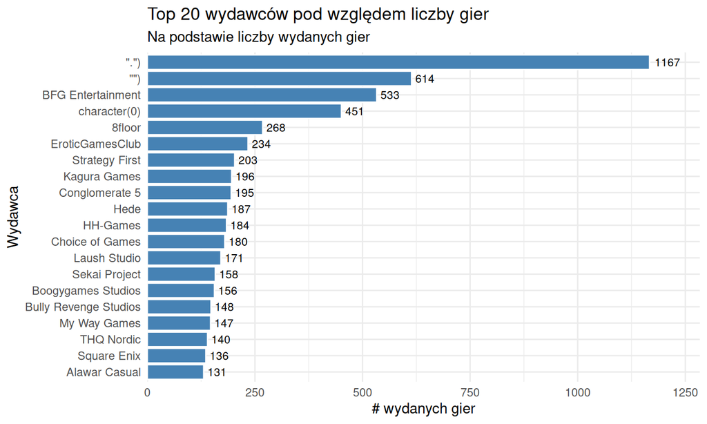

## Publishers

```r
publishers_clean %>%
  filter(publisher_list %in% top_20_publishers$publisher_list) %>%
  group_by(publisher_list) %>%
  summarise(median_price = median(Price)) %>%
  arrange(desc(median_price))
```

```
## # A tibble: 20 × 2
##    publisher_list          median_price
##    <chr>                          <dbl>
##  1 "BFG Entertainment"            20.0
##  2 "Square Enix"                  20.0
##  3 "8floor"                       15.0
##  4 "Kagura Games"                 15.0
##  5 "Sekai Project"                15.0
##  6 "\".\")"                       13.0
##  7 "THQ Nordic"                   11.2
##  8 "Hede"                          9.99
##  9 "\"\")"                         7.99
## 10 "Alawar Casual"                 6.99
## 11 "HH-Games"                      6.99
## 12 "Choice of Games"               5.99
## 13 "Strategy First"                4.99
## 14 "character(0)"                  4.99
## 15 "EroticGamesClub"               2.99
## 16 "Laush Studio"                  2.99
## 17 "Boogygames Studios"            1.99
## 18 "Bully Revenge Studios"         0.99
## 19 "Conglomerate 5"                0.99
## 20 "My Way Games"                  0.49
```

## Publishers

```r
games_unique <- games_clean %>%
  distinct(AppID, .keep_all = TRUE)

publisher_stats <- games_unique %>%
  group_by(Publishers) %>%
  summarise(
    game_count = n(),
    total_recs = sum(Recommendations, na.rm = TRUE),
    avg_recs_per_game = mean(Recommendations, na.rm = TRUE)
  ) %>%
  filter(game_count >= 5) %>% # Filters out "one-hit wonders" or tiny devs
  arrange(desc(total_recs))
```

```
## # A tibble: 10 × 4
##    Publishers game_count total_recs avg_recs_per_game
##    <list>          <int>      <dbl>             <dbl>
##  1 <chr [1]>          29    8301532           286260.
##  2 <chr [1]>         112    3502791            31275.
##  3 <chr [1]>         140    3355055            23965.
##  4 <chr [1]>          65    2104258            32373.
##  5 <chr [1]>          63    2020877            32077.
##  6 <chr [2]>          10    1893512           189351.
##  7 <chr [1]>           8    1665621           208203.
##  8 <chr [2]>          44    1619768            36813.
##  9 <chr [1]>          23    1530896            66561.
## 10 <chr [1]>          17    1362495            80147.
```

## Liczba godzin

## Związek z rekomendacjami

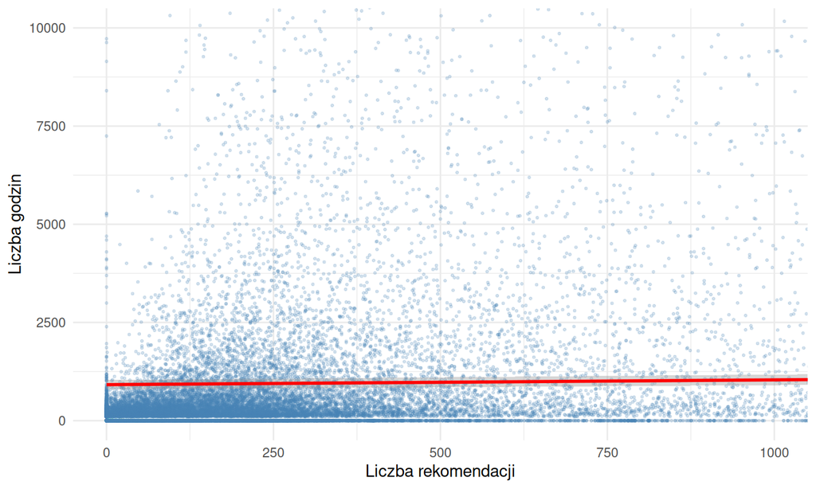

## Regresja wieloraka

W skali liniowej nic ciekawego…

```
##
## Call:
## lm(formula = Average_playtime_forever ~ Price + Recommendations +
##     Owners_Factor, data = games_unique)
##
## Residuals:
##     Min      1Q  Median      3Q     Max
##  -17314     -90     -65     -51 1677127
##
## Coefficients:
##                   Estimate Std. Error t value Pr(>|t|)
## (Intercept)      3.898e+03  3.837e+02  10.159  < 2e-16 ***
## Price            3.576e+00  1.581e+00   2.263 0.023661 *
## Recommendations  1.755e-03  1.189e-03   1.476 0.139867
## Owners_Factor.L  1.780e+04  2.038e+03   8.732  < 2e-16 ***
## Owners_Factor.Q  1.325e+04  1.901e+03   6.971 3.16e-12 ***
## Owners_Factor.C  9.189e+03  1.613e+03   5.697 1.22e-08 ***
## Owners_Factor^4  6.408e+03  1.425e+03   4.498 6.88e-06 ***
## Owners_Factor^5  4.857e+03  1.330e+03   3.651 0.000261 ***
## Owners_Factor^6  3.818e+03  1.245e+03   3.067 0.002160 **
## Owners_Factor^7  2.575e+03  1.103e+03   2.334 0.019606 *
## Owners_Factor^8  1.648e+03  9.285e+02   1.774 0.076006 .
## Owners_Factor^9  1.026e+03  7.617e+02   1.347 0.178128
## Owners_Factor^10 5.635e+02  6.262e+02   0.900 0.368137
## Owners_Factor^11 5.764e+02  5.103e+02   1.129 0.258710
## Owners_Factor^12 2.681e+02  3.792e+02   0.707 0.479473
## Owners_Factor^13 1.570e+02  2.567e+02   0.611 0.540870
## ---
## Signif. codes:  0 '***' 0.001 '**' 0.01 '*' 0.05 '.' 0.1 ' ' 1
##
## Residual standard error: 6108 on 115273 degrees of freedom
## Multiple R-squared:  0.003285,   Adjusted R-squared:  0.003155
## F-statistic: 25.32 on 15 and 115273 DF,  p-value: < 2.2e-16
```

## Regresja wieloraka

```
##
## Call:
## lm(formula = log1p(Average_playtime_forever) ~ log1p(Price) +
##     log1p(Recommendations) + Owners_Factor, data = games_unique)
##
## Residuals:
##     Min      1Q  Median      3Q     Max
## -7.5383 -0.3595 -0.3030  0.0541 14.1068
##
## Coefficients:
##                         Estimate Std. Error t value Pr(>|t|)
## (Intercept)             1.766844   0.069569  25.397  < 2e-16 ***
## log1p(Price)            0.055758   0.004712  11.832  < 2e-16 ***
## log1p(Recommendations)  0.538991   0.002256 238.957  < 2e-16 ***
## Owners_Factor.L         2.872255   0.371403   7.734 1.05e-14 ***
## Owners_Factor.Q        -0.477095   0.369233  -1.292  0.19632
## Owners_Factor.C         1.558965   0.340500   4.578 4.69e-06 ***
## Owners_Factor^4         0.545630   0.315597   1.729  0.08383 .
## Owners_Factor^5         0.007656   0.298698   0.026  0.97955
## Owners_Factor^6         0.526475   0.279909   1.881  0.05999 .
## Owners_Factor^7         0.229918   0.248336   0.926  0.35453
## Owners_Factor^8         0.185987   0.210095   0.885  0.37602
## Owners_Factor^9         0.003565   0.173768   0.021  0.98363
## Owners_Factor^10        0.116468   0.144058   0.808  0.41882
## Owners_Factor^11        0.284796   0.118137   2.411  0.01592 *
## Owners_Factor^12        0.291840   0.088061   3.314  0.00092 ***
## Owners_Factor^13        0.162914   0.059711   2.728  0.00637 **
## ---
## Signif. codes:  0 '***' 0.001 '**' 0.01 '*' 0.05 '.' 0.1 ' ' 1
##
## Residual standard error: 1.421 on 115273 degrees of freedom
## Multiple R-squared:  0.6202, Adjusted R-squared:  0.6202
## F-statistic: 1.255e+04 on 15 and 115273 DF,  p-value: < 2.2e-16
```

## Regresja wieloraka

Tutaj już bardziej ciekawo. Najpierw, Intercept: \(e^{1.767} - 1 \approx 4,85\) Residua \(e^{1.421} \approx 4.14\)

## DLC

## Związek z liczbą godzin

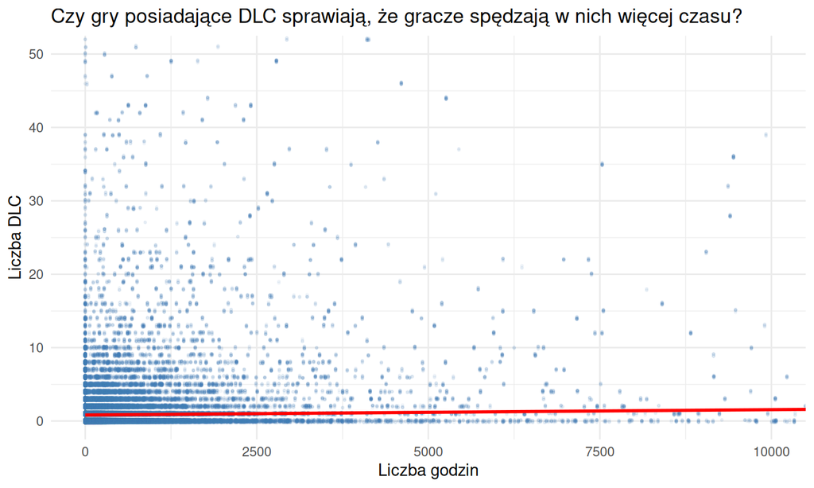

## Związek z liczbą właścicieli

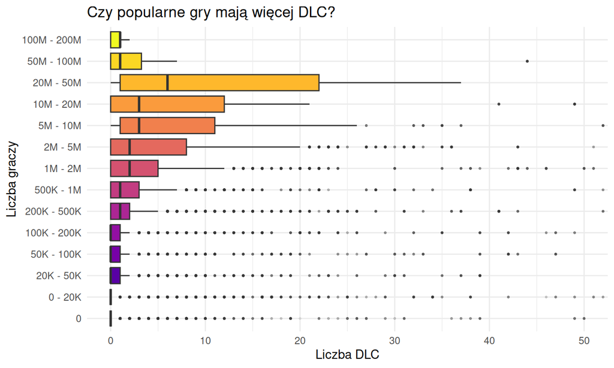

## DLC

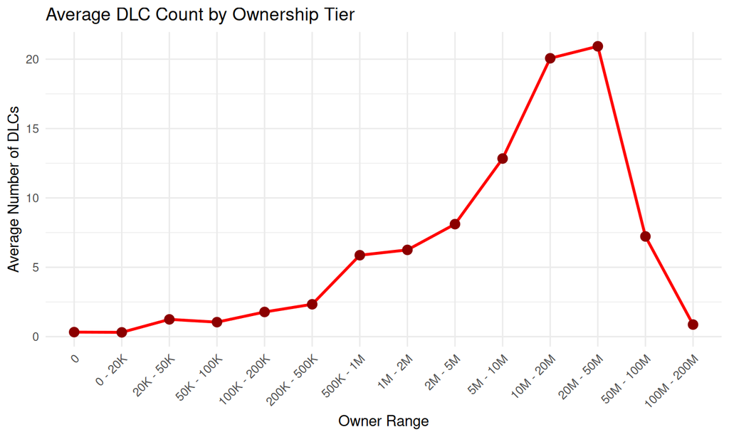